# Weekly Energy Charts

August 19, 2022

[Sign up here to get on our email list](https://docs.google.com/forms/d/e/1FAIpQLSckqeGjUvIlhveVyjmkXe913tzQRLANqPNQzEZTUQD2hQxH8g/viewform?usp=pp_url)

# Featured Stories

## (Overly?) Optimistic on AB renewables

#### Marc Vermette

On August 17, US President Joe Biden signed the [Inflation Reduction Act (IRA) of 2022](https://www.congress.gov/bill/117th-congress/house-bill/5376/text) into law.

This act includes the largest climate/energy spending package in U.S. history. Of the $600 billion in spending, over 60% is dedicated to supporting renewable energy and climate resilience.

The IRA is expected to contribute to a nationwide reduction of carbon emissions by roughly 40% in 2030.

It is estimated that the IRA will lead to the installation of 950 million solar panels, 120,000 wind turbines, and 2,300 grid-scale battery plants.

The policy package is also aimed at creating energy savings for Americans.

7.5 million more families are expected to be able install solar in their homes with the new 30% tax credit, which could save families approximately $9,000 over the life of a system (at least $300 per year).

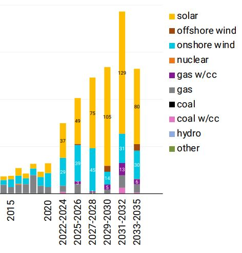

Historical capacity additions and projections under the Act, in GW. Image: Princeton

[Original article](https://pv-magazine-usa.com/2022/08/16/the-largest-climate-and-energy-package-in-u-s-history-becomes-law/)

## Europe’s Largest Solar Plant

#### [Debosree Mukherjee](https://www.linkedin.com/in/debosree-mukherjee/)

Last week, Spanish multinational energy company Iberdrola began operations at Europe’s largest solar plant. The [590 MW Francisco Pizarro solar photovoltaic (PV) project](https://www.power-technology.com/news/iberdrola-francisco-pizarro/) is in Extremadura, Spain. This plant has helped to increase the renewable energy output in the country and decrease its dependence on fossil fuels. One of Iberdrola’s largest facilities, the Francisco Pizarro solar facility was built with an investment of more than 300 million euros. The solar plant consists of more than 1.5 million solar PV modules and has the capacity to generate enough clean energy to [power more than 334,000 homes](https://www.bloomberg.com/news/articles/2022-08-10/sun-drenched-spain-turns-on-europe-s-biggest-solar-power-plant). It will also offset 150,000 tonnes of carbon dioxide emissions per year. Spanish power prices are currently almost 3x higher than the 5-year seasonal average due to Russian gas cuts. Spain is betting that increasing solar generation will help bring these prices down. Spain has a goal to generate 75% of its electricity from renewables by 2030, a big increase from the 47% market share in 2021.

## EIA expects renewables to make up 22% of total US electricity generation for 2022

#### [Yousaff Habib](https://www.linkedin.com/in/yousaff-habib-6684891a5/)

[figure not shown]

Data source: U.S. Energy Information Administration, Short-Term Energy Outlook (STEO)

This prediction is taken from the EIA’s Short Term Energy Outlook report, which covered 11 electricity markets. Analysis noted how environmental factors (such as drought-constrained hydropower) limited generation. Despite these limitations, overall generation still increased, a promising sign for future years, when some of these environmental factors may not have such deleterious effects.

The report also analyzes how each region has grown their renewable generation. Texas’s ERCOT is particularly noteworthy – in 2013, they were at a below average 10%, and have since jumped to a significantly above average 32% in 2022. With growing concerns about the power grid in Texas, this is promising news.

[figure not shown]

Data source: U.S. Energy Information Administration, Short-Term Energy Outlook (STEO)

The EIA predicts that, in 2023, renewables will grow to 24% of total generation as coal and other fossil fuel plants are retired in favor of more sustainable ones. You can read the full STEO report [here](https://www.eia.gov/outlooks/steo/).

# Oil

## Weekly Crude Prices

### Feature Crude

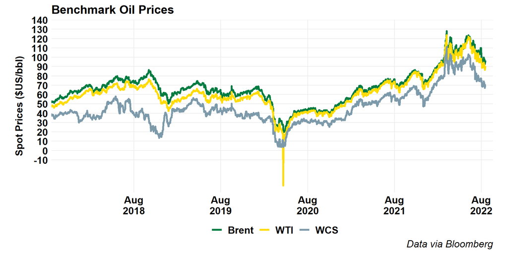

### Alberta Crude

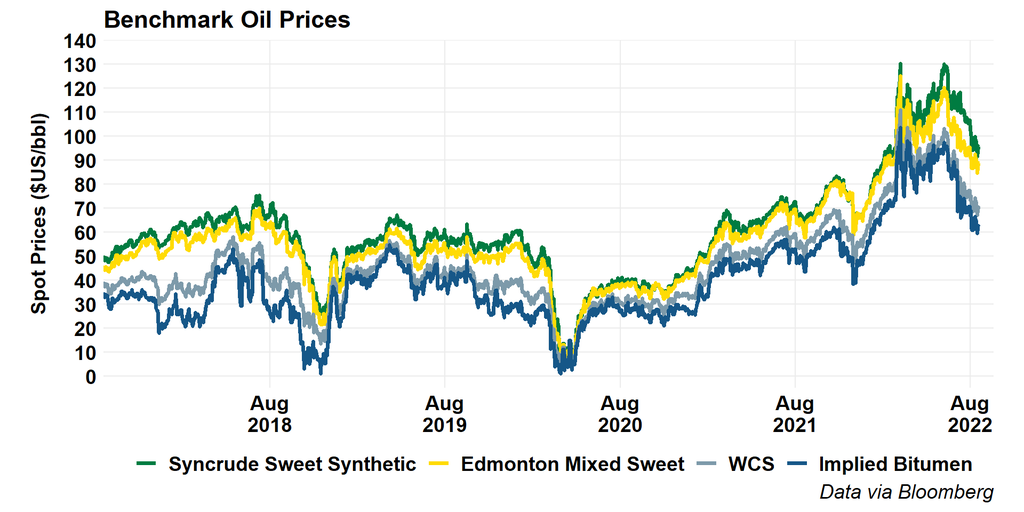

### Alberta Crude (Short)

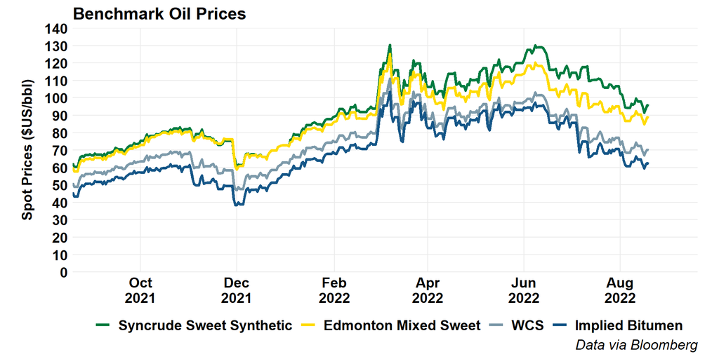

### US Crude

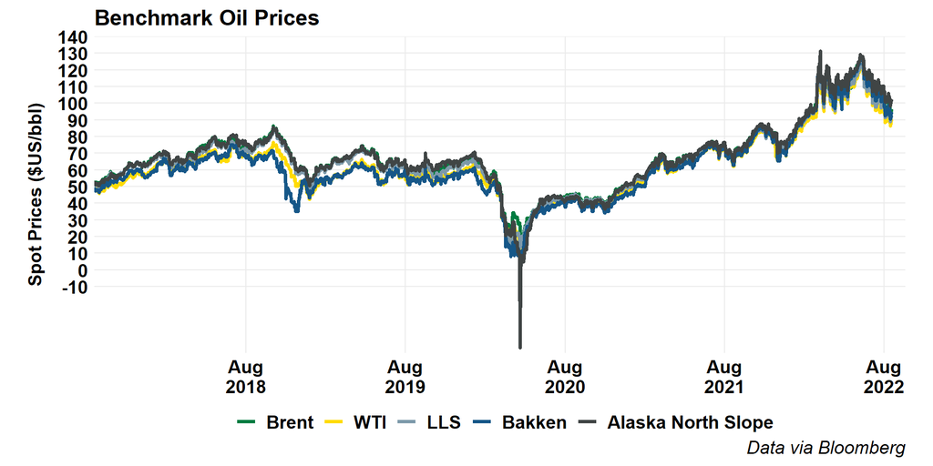

### Global Crude

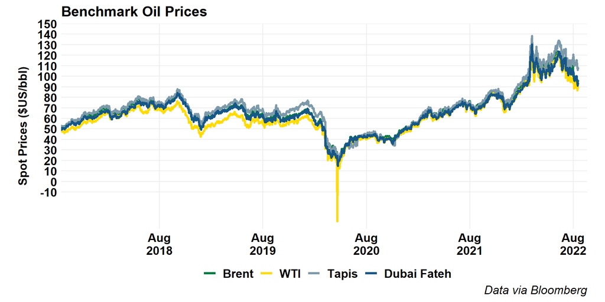

## Oil Price Differentials

### Brent-WTI

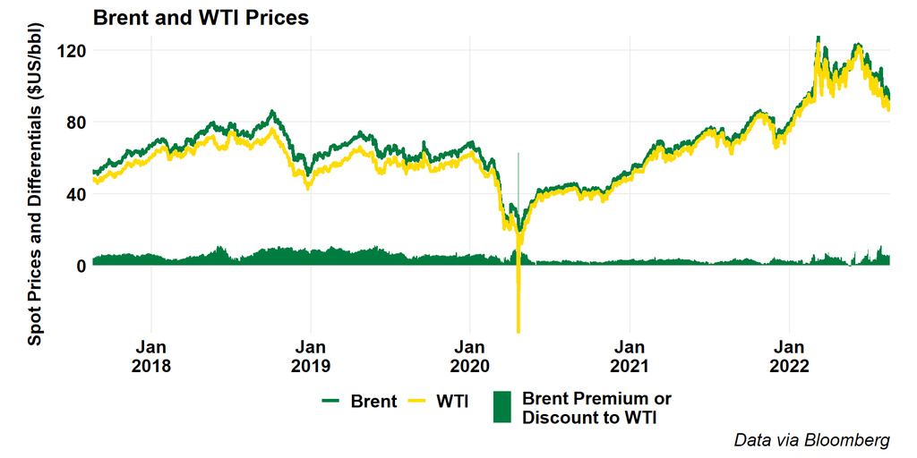

### WTI-WCS

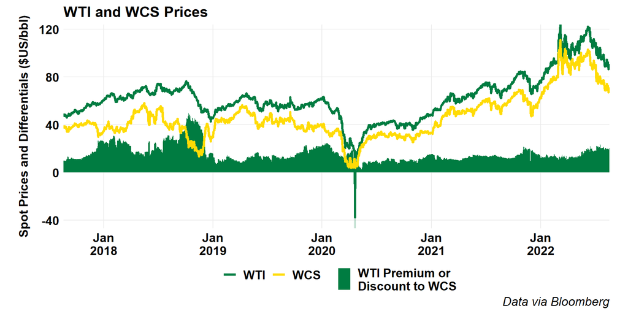

### WTI-WCS (Short)

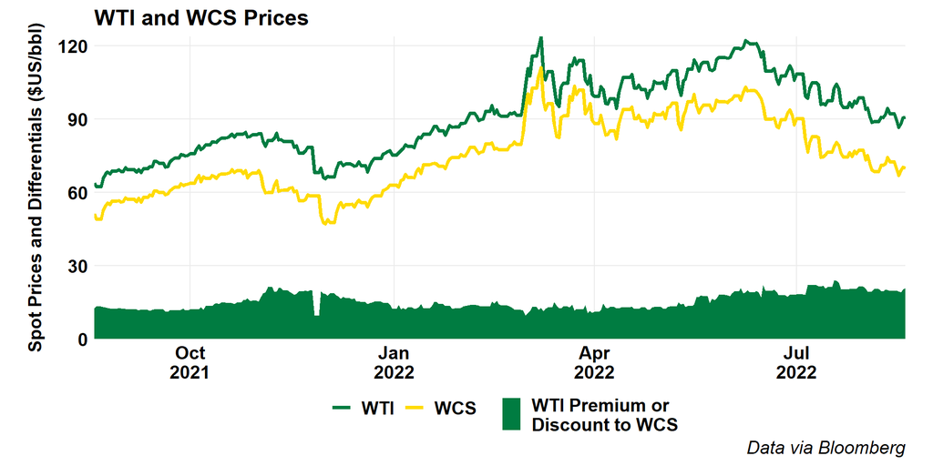

### Maya-WCS

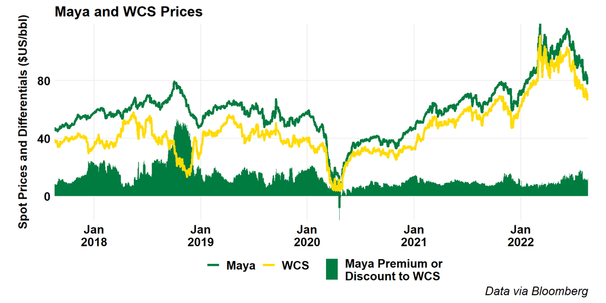

### WTI Cushing vs MEH

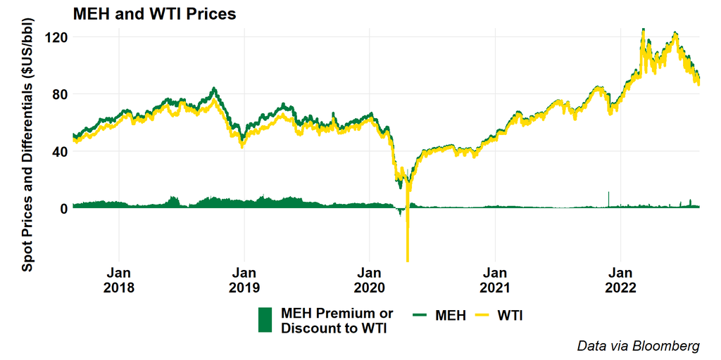

## Forward Curves

### WTI

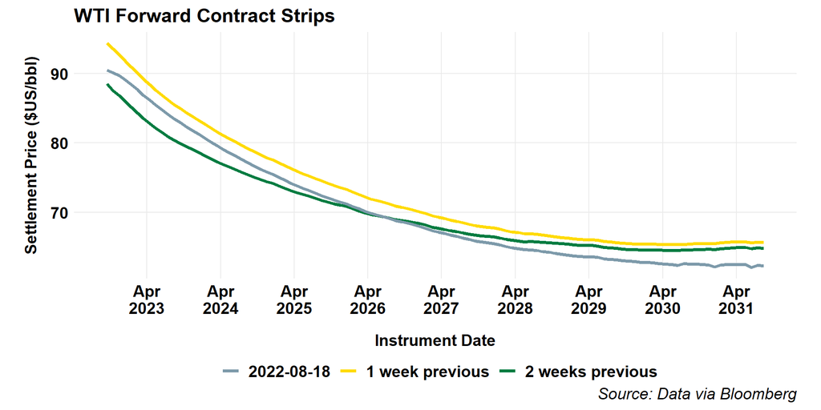

### Brent

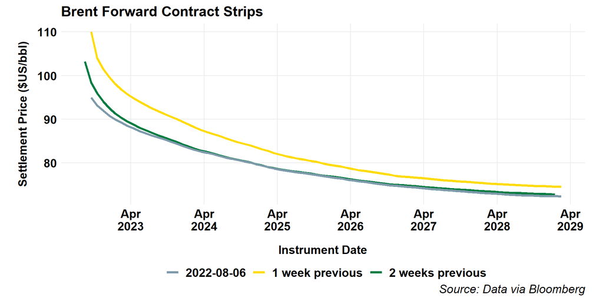

## Canadian Crude Supply and Disposition

### Production

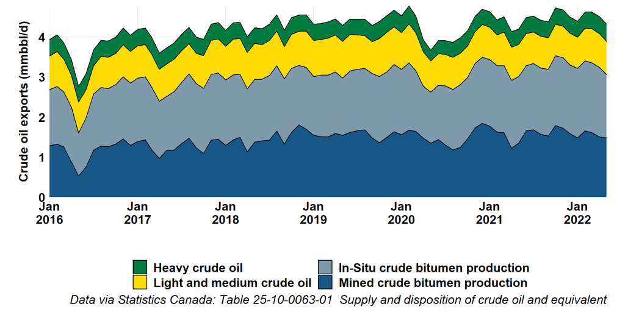

### Imports

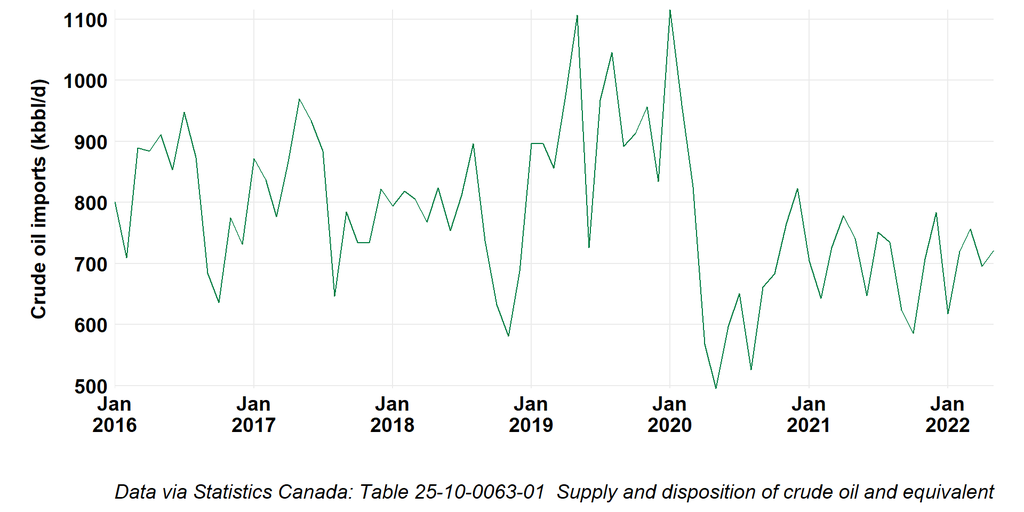

### Exports

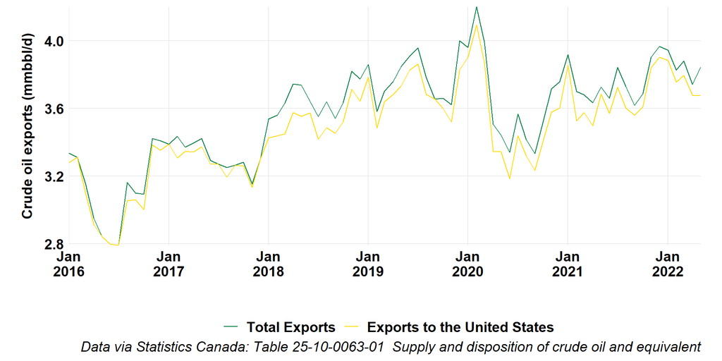

### Rail Exports

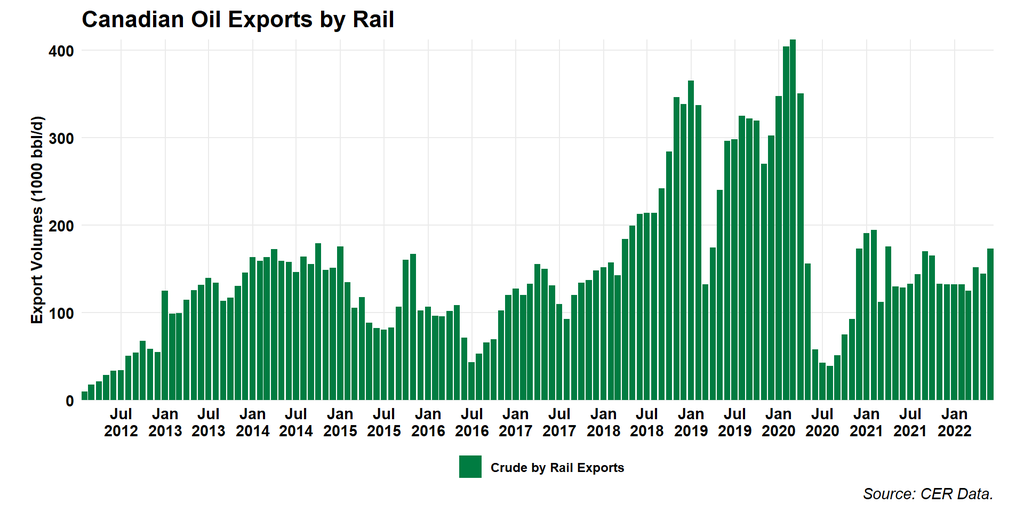

## US Oil

### Production

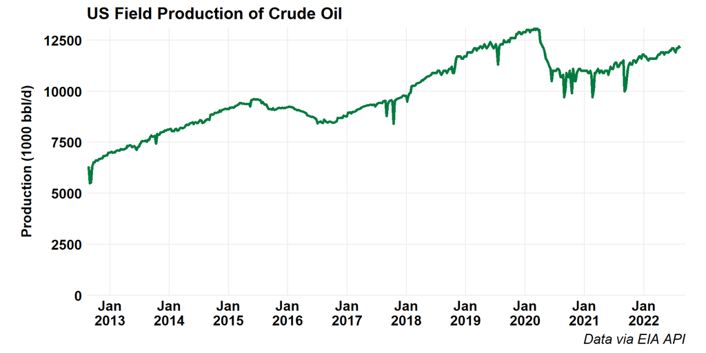

### LTO Production by Play

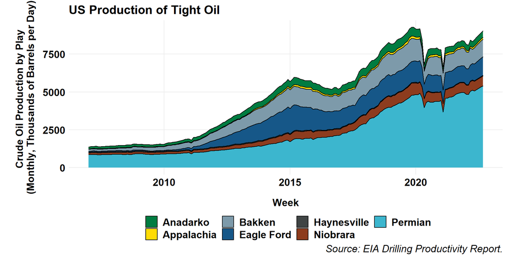

### Net Imports

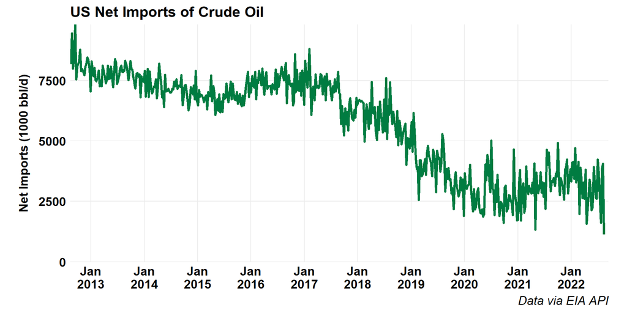

### Oil and Product Net Imports

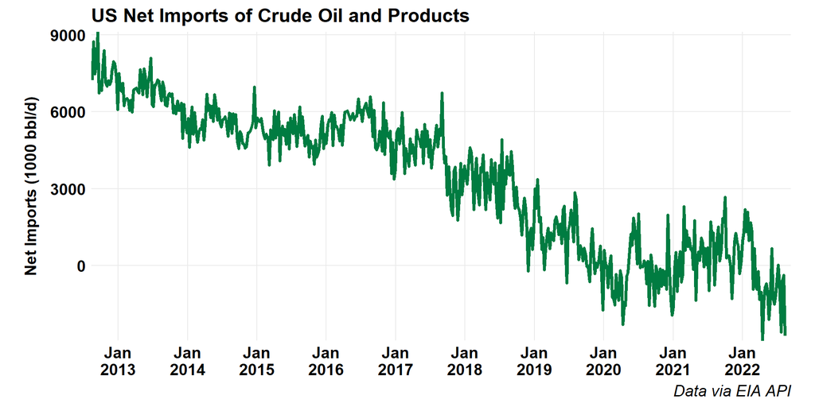

### Inventories

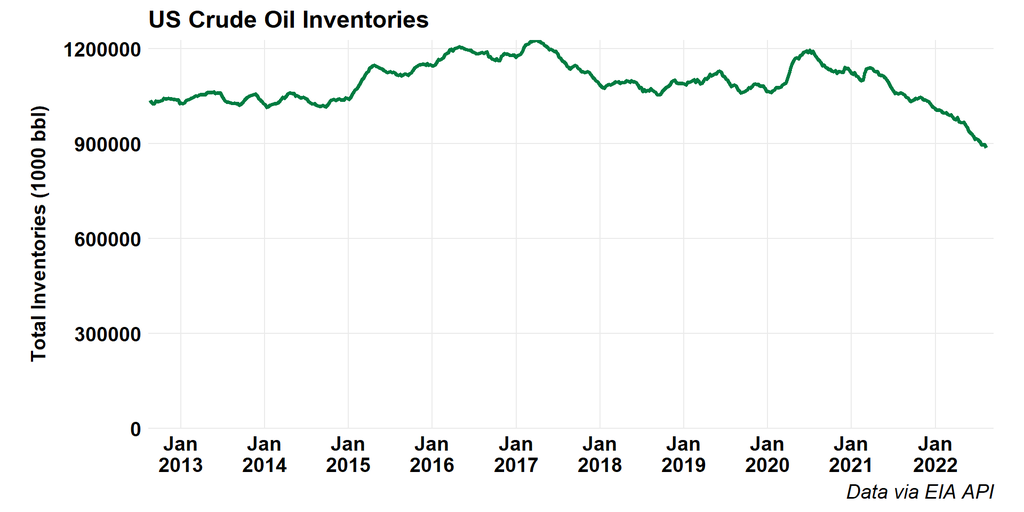

# Refined Products

## Canadian Gasoline Prices

### Map

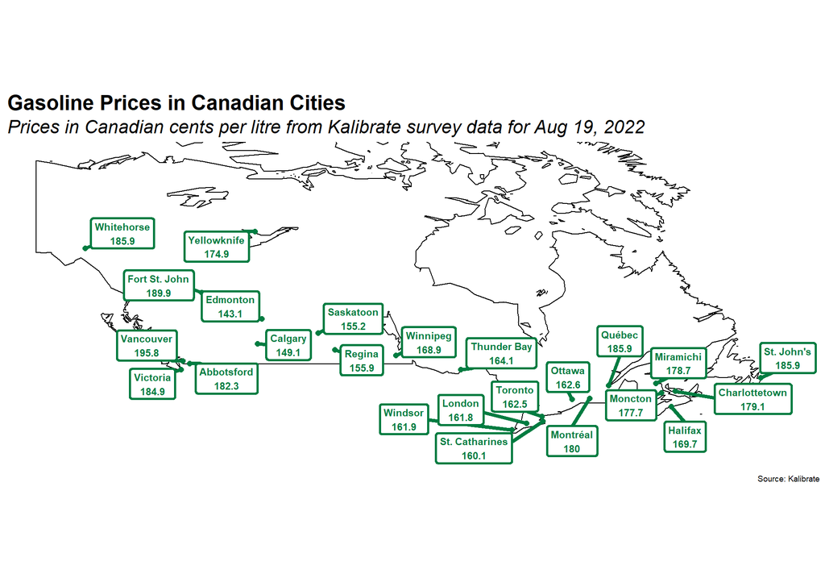

### Historic Gasoline Prices

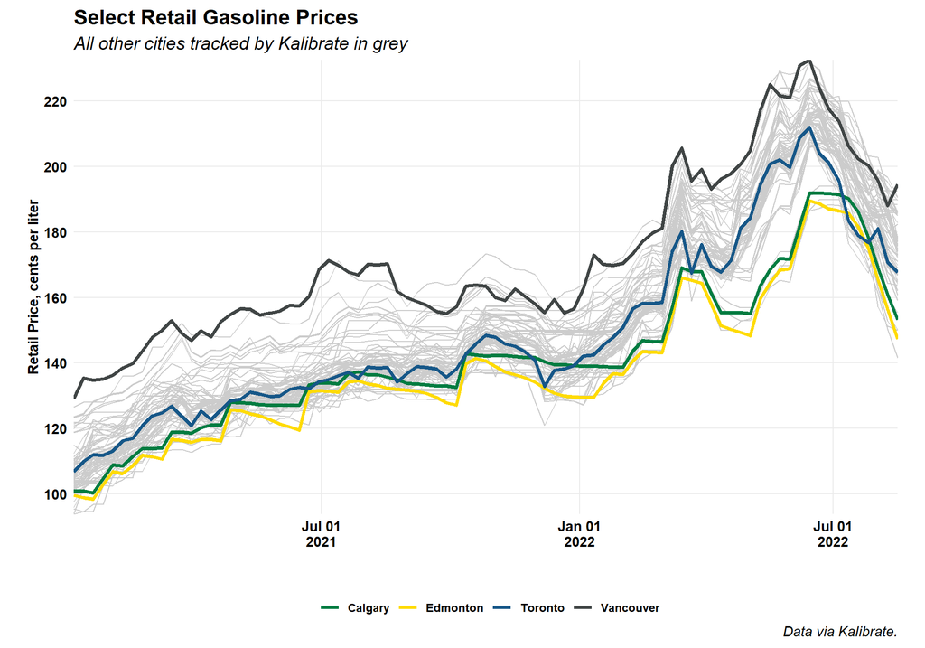

### Historic Gasoline Prices in BTC

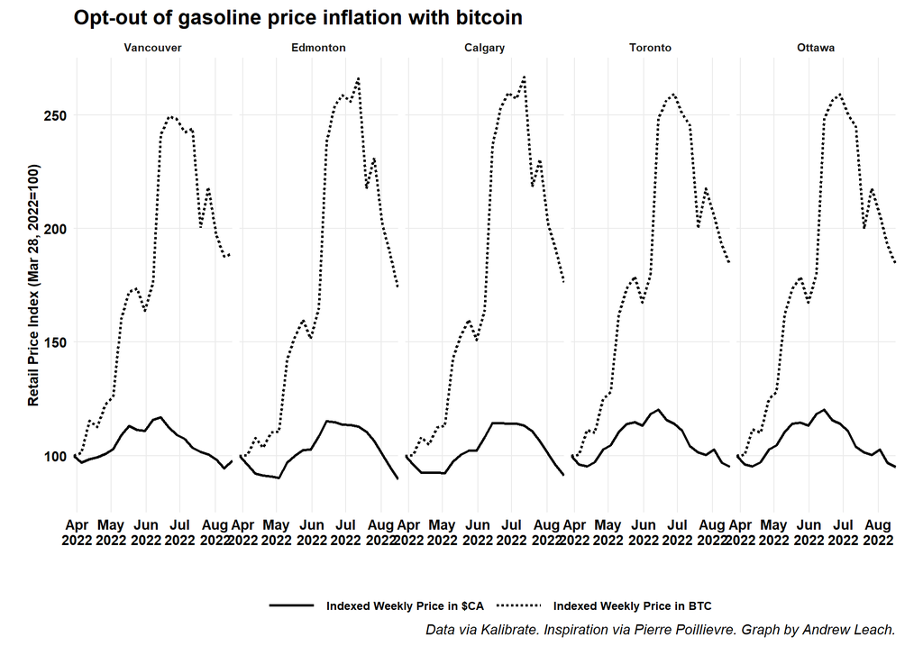

### Historic Diesel Prices

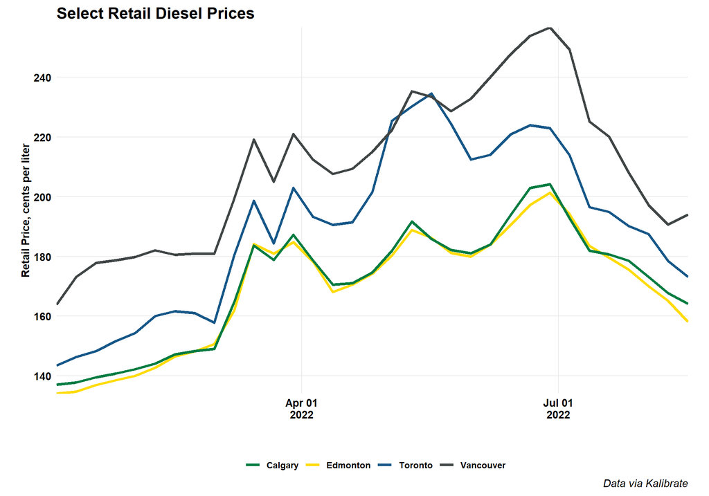

## Canadian Refinery Runs

### Canadian Refinery Runs

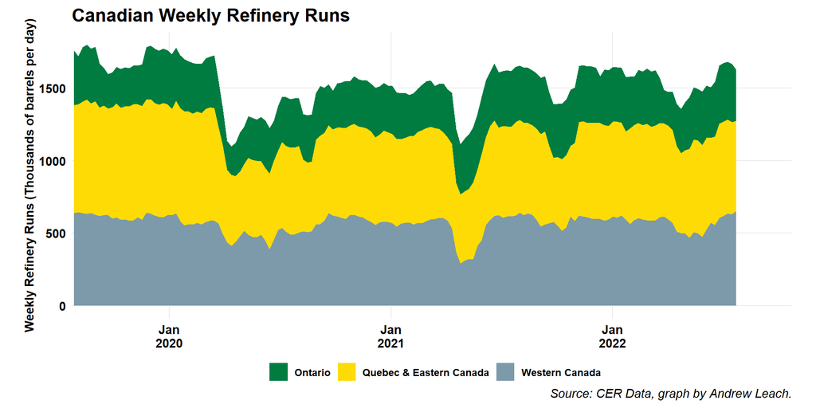

### Western Canada Refinery Runs

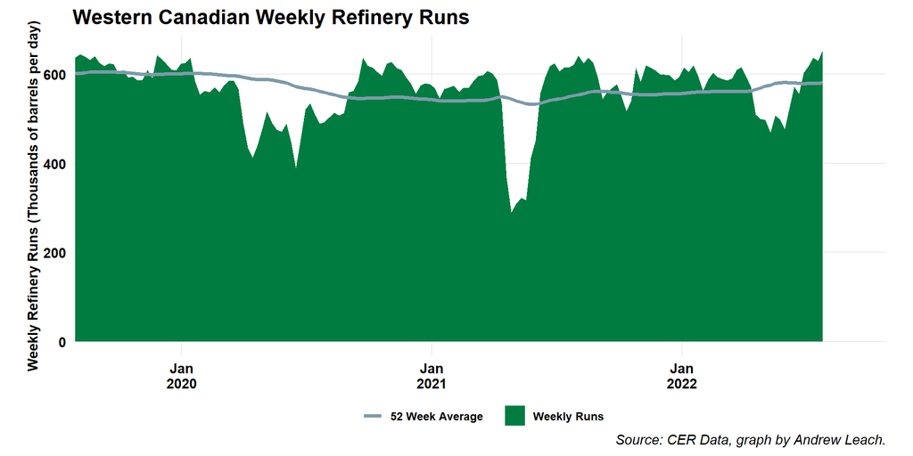

# Natural Gas

## Natural Gas Market Summary

### Feature Gas

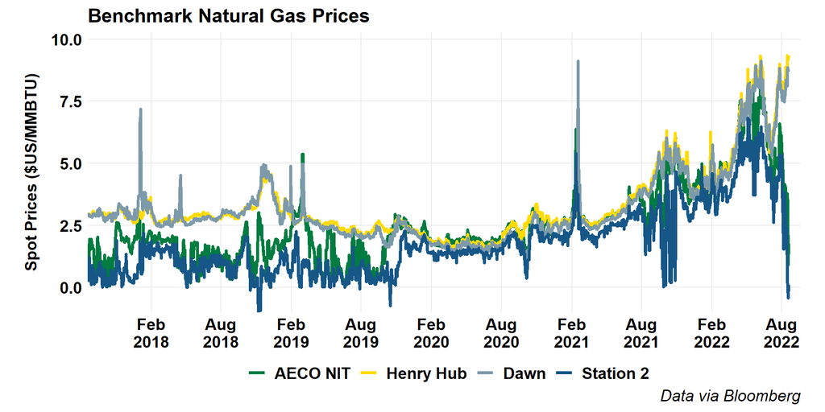

### Feature Gas (Short)

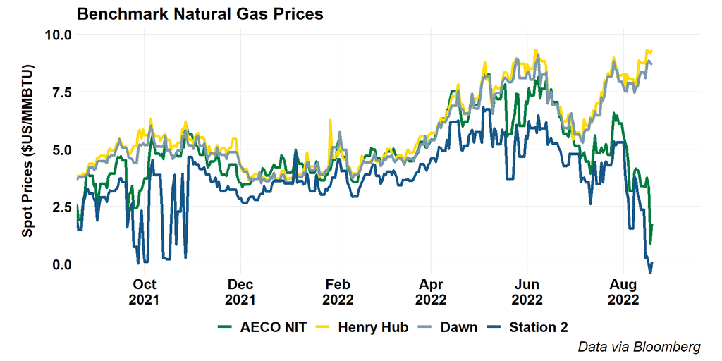

### Global Gas

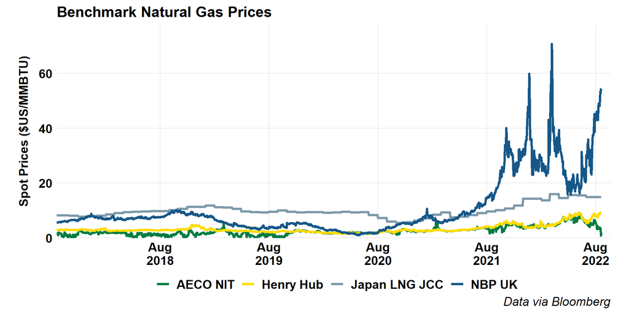